# Assignment BioSB course

#### Modelling chronic lymphocytic leukemia cell kinetics

Petrus Bult - Eindhoven University of Technology

**notes on the codebase used for the assigment**

Most code to do the assignment is in the module SimODEs_BioSB. This is done to keep this notebook as clean and minimalistic as possible. Many of the functions part of the module were already created by me for my own research - and copied over to this slimmed-down module for the assignment. The plotting functions (plotting.jl) and the functionality regarding dataloading (data_loading.jl) were specifically created for this assignment. Most of the other code worked right away after defining the model in ode_models.jl (combination of creating a struct - based on the AbstractODEModel struct and defining the ode_func! (the ODE system of equations) method to work on that specific struct)."

```julia
# Load the module created for this assignment & other required modules
using Pkg
Pkg.activate("..")
Pkg.instantiate()

using SimODEs_BioSB
using Plots
```

```
  Activating project at `c:\Repos\dynamic-modeling-in-systems-biology`
```

#### Load and plot the provided .csv data

```julia
# Load_cll_data returns an 'observed_data' struct, that contains time points and measurements (and optionally weights - inverse stds - of the measurements)
dataset1 = load_cll_data("data/dataset1.csv")
dataset2 = load_cll_data("data/dataset2.csv")
```

```
Dict{String, ObservedData} with 2 entries:
  "tissue" => ObservedData([0.0, 45.0, 90.0], [3.0525e12, 7.0412e11, 2.1437e11]…
  "blood"  => ObservedData([0.0, 15.0, 30.0, 45.0, 60.0, 75.0, 90.0, 105.0, 120…
```

#### Plot data from both datasets

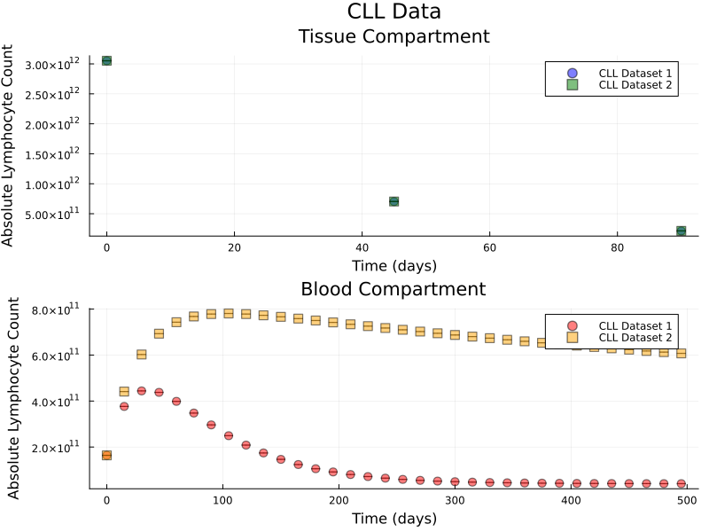

```julia
plot_cll(observed=[dataset1, dataset2], data_labels=["CLL Dataset 1", "CLL Dataset 2"], alpha=0.5)
```

```julia
# Starting values from the data
tissue_0 = dataset1["tissue"].values[1]
blood_0 = dataset1["blood"].values[1]

# Lower and upper bounds of the parameters
lb = [5e-5, 1e-4, 1e-4, 1e5] # Lower bound parameters
lb_0 = [0.75*tissue_0, 0.75*blood_0] # Lower bound initial conditions
ub = [0.5, 0.1, 0.1, tissue_0] # Upper bound parameters
ub_0 = [1.25*tissue_0, 1.25*blood_0] # Upper bound initial conditions

slow_model =  WodartzModel((m=0.015, d1=0.1, d2=0.002, c=5e10), (tissue=tissue_0, blood=blood_0));
fast_model =  WodartzModel((m=0.015, d1=0.1, d2=0.02, c=5e10), (tissue=tissue_0, blood=blood_0));

sol_slow = simulate(slow_model, tspan = (0.0, 500.0));
sol_fast = simulate(fast_model, tspan = (0.0, 500.0));
```

#### Plot both the fast and the slow model

The fast and slow models are created with the d2 to 0.02 and 0.002 respectively. The other parameters have been chosen such that the output is at least on the same scale as the provided data. (ofcourse once we estimate the parameters, we have a better result of what the parameters should be - but I briefly tuned them manually for now).

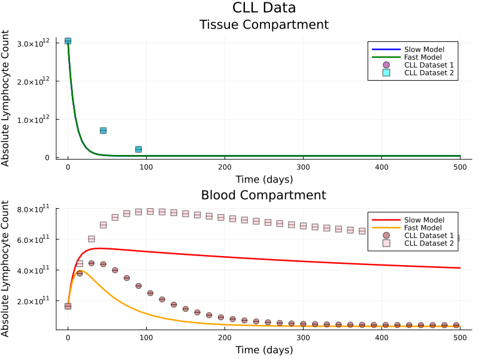

```julia
plot_cll(observed=[dataset1, dataset2], solutions=[sol_slow, sol_fast], data_labels=["CLL Dataset 1", "CLL Dataset 2"], solution_labels=["Slow Model", "Fast Model"], alpha=0.5)
```

### Derivation steady state values

The ODE system is given by:

$$\frac{dx}{dt} = -mx - d_1(x - c)$$ $$\frac{dy}{dt} = mx - d_2 y$$

At steady state -> both derivatives to 0.

**For the tissue compartment ($x_{ss}$):**

$$\frac{dx}{dt} = 0 \implies -mx - d_1(x - c) = 0 \implies x_{ss} = \frac{d_1 c}{m + d_1}$$

**For the blood compartment ($y_{ss}$):**

$$\frac{dy}{dt} = 0 \implies mx - d_2 y = 0 \implies y_{ss} = \frac{m x_{ss}}{d_2}$$

Substituting $x_{ss}$: $$y_{ss} = \frac{m}{d_2} \cdot \frac{d_1 c}{m + d_1}$$

### Stability

To check stability, look at Jacobian at the steady state.

**Jacobian Matrix:**

$$J = \begin{bmatrix} \frac{\partial f_1}{\partial x} & \frac{\partial f_1}{\partial y} \\ \frac{\partial f_2}{\partial x} & \frac{\partial f_2}{\partial y} \end{bmatrix} = \begin{bmatrix} -(m + d_1) & 0 \\ m & -d_2 \end{bmatrix}$$

**Eigenvalues:**

The eigenvalues are then given by: $$\lambda_1 = -(m + d_1)$$ $$\lambda_2 = -d_2$$

Both eigenvalues are **negative** (since $m$, $d_1$, and $d_2$ are all positive parameters). This means the steady state is **asymptotically stable**.

### Data Simulation

(skipped)

### Parameter Inference

Assignment: implement & combine global search with local search.

**Alternatively : sample many starting points & optimize from best x.**

(I already had some functionality lying around for this - so I'll do this first). The fit_model method (estimation.jl) is responsible for finding the best parameter values. For this it takes the weighted_sse (can also be found in estimation.jl) between the model simulation and observed data as loss function. It now uses LBFGS as optimization method - but can be easily altered. By finding the parameters that minimize the sse-loss, the 'best' parameters are obtained. The code below first does latin-hypercube sampling of potential starting points that lie between the lower and upper bound. It currently does 10000 initial samples (n_samples) - it then calculates the loss for all of them, picks the best 100 (n_starts) to optimize further (local optimization). The final parameters are the ones minimizing the loss best.

NOTE: the multistart with so many samples is a bit overkill - when I started with local optmization from the 'guesed' starting point I also already found the parameters.

```julia
using OptimizationOptimJL

# Initialize wodartz_model -> parameters will be estimated (so specific values here are of less importance (only matter for starting position if you don't sample a collection of starting points)).
wodartz_model = WodartzModel((m=0.015, d1=0.05, d2=0.002, c=1e10), (tissue=tissue_0, blood=blood_0));

# Create config struct for multistart of the fit_model method
# e.g. start with 10000 starting points (n_samples - sampled with latin hypercube sampling (method=:lhs)), pick 100 best ones (n_starts) to do local optimization from.
# (NOTE: this is a bit overkill -> I already saw that both datasets give good convergence already from the 'guessed' starting points given above).
ms = MultiStartConfig(n_samples=10000, n_starts=100, method=:lhs, parallel=true, seed=1)

obs_data_vector1 = [dataset1["tissue"], dataset1["blood"]]
obs_data_vector2 = [dataset2["tissue"], dataset2["blood"]]

# Fit on 1st dataset
fitted_model1, result = fit_model(
    wodartz_model, obs_data_vector1, (:m, :d1, :d2, :c),
    lb=lb,
    ub=ub,
    optimizer=LBFGS(),
    maxiters=1000,
    multistart=ms
)
sol_fit1 = simulate(fitted_model1, tspan=(0.0, 500.0));

fitted_model2, result = fit_model(
    wodartz_model, obs_data_vector2, (:m, :d1, :d2, :c),
    lb=lb,
    ub=ub,
    optimizer=LBFGS(),
    maxiters=1000,
    multistart=ms
)

sol_fit2 = simulate(fitted_model2, tspan=(0.0, 500.0));
```

```
┌ Info: Optimizing from 100 best starts (losses: [1.60152564134768e23, 2.2182489244408255e23, 2.2552786238746216e23, 2.2726628043397328e23, 2.417172165644557e23, 2.4984380957944932e23, 2.7291390650905898e23, 2.746338840999867e23, 2.885185046067183e23, 2.9564158458903258e23, 2.985759106954351e23, 3.0…
└ @ SimODEs_BioSB C:\Repos\dynamic-modeling-in-systems-biology\SimODEs_BioSB\src\estimation.jl:333
┌ Info: Best final loss: 1.9377632030619018e18
└ @ SimODEs_BioSB C:\Repos\dynamic-modeling-in-systems-biology\SimODEs_BioSB\src\estimation.jl:341
┌ Info: Optimizing from 100 best starts (losses: [2.9574974714171447e23, 4.132038359728401e23, 5.362052828426577e23, 6.155604983393808e23, 6.603953754572092e23, 6.638821157414875e23, 6.88414151786733e23, 7.253410534947985e23, 7.366941302332453e23, 7.45520881708089e23, 7.46848150507889e23, 7.50644555…
└ @ SimODEs_BioSB C:\Repos\dynamic-modeling-in-systems-biology\SimODEs_BioSB\src\estimation.jl:333
┌ Info: Best final loss: 7.502861304170243e17
└ @ SimODEs_BioSB C:\Repos\dynamic-modeling-in-systems-biology\SimODEs_BioSB\src\estimation.jl:341
```

#### Plot fitted model results

Check whether the models - after parameter estimation - indeed correspond to the data.

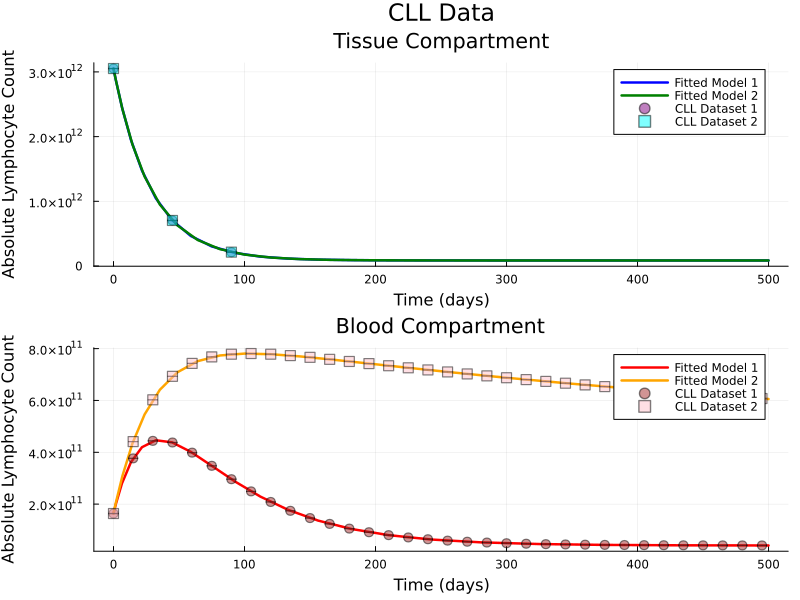

```julia
plot_cll(observed=[dataset1, dataset2], solutions=[sol_fit1, sol_fit2], data_labels=["CLL Dataset 1", "CLL Dataset 2"], solution_labels=["Fitted Model 1", "Fitted Model 2"], alpha=0.5)
```

```julia
## Print fitted parameters
println("Fitted parameters for Dataset 1:")
for (param, value) in pairs(fitted_model1.parameters)
    println("$(param) = $(value)")
end

println("\nFitted parameters for Dataset 2:")
for (param, value) in pairs(fitted_model2.parameters)
    println("$(param) = $(value)")
end
```

```
Fitted parameters for Dataset 1:
m = 0.0079591063651349
d1 = 0.026935276147074843
d2 = 0.01695475643596446
c = 1.1099048438356499e11

Fitted parameters for Dataset 2:
m = 0.0079632067963389
d1 = 0.02687709684846521
d2 = 0.0016930197061669266
c = 1.1079810314344058e11
```

#### Global + local search strategy

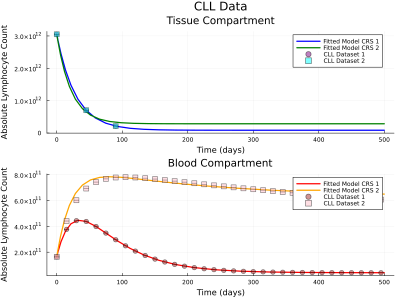

```julia
config = CRSConfig(n_population=200, rel_tol=0.01, verbose=false, seed=42, max_iterations=10000)
fitted_model_crs1, result_crs1 = fit_model_crs(
    wodartz_model, obs_data_vector1, (:m, :d1, :d2, :c),
    lb=lb, ub=ub,
    config=config
)

sol_fit_crs1 = simulate(fitted_model_crs1, tspan=(0.0, 500.0));

fitted_model_crs2, result_crs2 = fit_model_crs(
    wodartz_model, obs_data_vector2, (:m, :d1, :d2, :c),
    lb=lb, ub=ub,
    config=config
)

sol_fit_crs2 = simulate(fitted_model_crs2, tspan=(0.0, 500.0));

# Plot result against data again
plot_cll(observed=[dataset1, dataset2], solutions=[sol_fit_crs1, sol_fit_crs2], data_labels=["CLL Dataset 1", "CLL Dataset 2"], solution_labels=["Fitted Model CRS 1", "Fitted Model CRS 2"], alpha=0.5)
```

Print found parameters with CRS

```julia
## Print fitted parameters
println("Fitted parameters for Dataset 1:")
for (param, value) in pairs(fitted_model_crs1.parameters)
    println("$(param) = $(value)")
end

println("\nFitted parameters for Dataset 2:")
for (param, value) in pairs(fitted_model_crs2.parameters)
    println("$(param) = $(value)")
end
```

```
Fitted parameters for Dataset 1:
m = 0.007976573176124092
d1 = 0.0269232456719673
d2 = 0.016995506688791354
c = 1.1183138677351422e11

Fitted parameters for Dataset 2:
m = 0.010592755973230603
d1 = 0.03476126416314383
d2 = 0.004834410440516374
c = 3.7311170661913367e11
```

#### Further improvement with local optimization

The global search hit the max iteration bounds -> as can be seen in the plot above, the final result is not great yet. We can continue with local optimization from the current best parameters (found with crs).

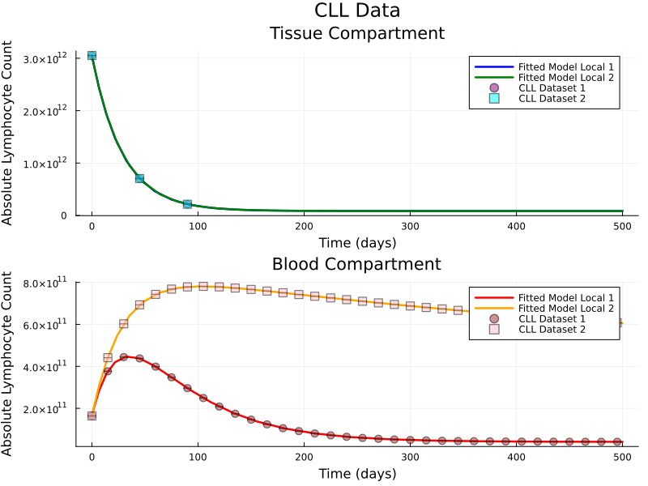

```julia
fitted_model_local1, _ = fit_model(
    fitted_model_crs1, obs_data_vector1, (:m, :d1, :d2, :c),
    lb=lb,
    ub=ub,
    optimizer=LBFGS(),
    maxiters=1000,
)

sol_fit_local1 = simulate(fitted_model_local1, tspan=(0.0, 500.0));

fitted_model_local2, _ = fit_model(
    fitted_model_crs2, obs_data_vector2, (:m, :d1, :d2, :c),
    lb=lb,
    ub=ub,
    optimizer=LBFGS(),
    maxiters=1000,
)

sol_fit_local2 = simulate(fitted_model_local2, tspan=(0.0, 500.0));

plot_cll(observed=[dataset1, dataset2], solutions=[sol_fit_local1, sol_fit_local2], data_labels=["CLL Dataset 1", "CLL Dataset 2"], solution_labels=["Fitted Model Local 1", "Fitted Model Local 2"], alpha=0.5)
```

Print the found parameters again -> are (almost) identical to previously found parameters (multiple starting locations with lhs sampling).

```julia
## Print fitted parameters
println("Fitted parameters for Dataset 1:")
for (param, value) in pairs(fitted_model_local1.parameters)
    println("$(param) = $(value)")
end

println("\nFitted parameters for Dataset 2:")
for (param, value) in pairs(fitted_model_local2.parameters)
    println("$(param) = $(value)")
end
```

```
Fitted parameters for Dataset 1:
m = 0.007959106365134892
d1 = 0.02693527614707484
d2 = 0.01695475643596443
c = 1.1099048438356444e11

Fitted parameters for Dataset 2:
m = 0.007963206796338941
d1 = 0.026877096848465315
d2 = 0.0016930197061669763
c = 1.1079810314344583e11
```

### Practical Identifiability

Produce the parameter covariance matrix.

```julia
using ForwardDiff, LinearAlgebra

"""
Compute parameter covariance matrix from the Hessian of the loss function.
Returns covariance matrix, standard errors, and correlation matrix.
"""
function compute_covariance(loss_fn, n_obs, param_values)
    # Compute Hessian at the optimum using ForwardDiff module
    hessian = ForwardDiff.hessian(p -> loss_fn(p, nothing), param_values)

    # Covariance matrix is inverse of Hessian (for maximum likelihood/least squares)
    # We need to scale by the residual variance
    # For weighted least squares: Cov = H^(-1) * σ²
    # where σ² ≈ SSE / (n_observations - n_parameters)

    n_params = length(param_values)

    # Compute residual variance (SSE at optimum)
    sse = loss_fn(param_values, nothing)
    residual_variance = sse / (n_obs - n_params)

    # Covariance matrix (handle potential singularity)
    cov_matrix = try
        inv(hessian) * residual_variance
    catch
        @warn "Hessian is singular, using pseudo-inverse"
        pinv(hessian) * residual_variance
    end

    # Standard errors (square root of diagonal)
    # Diagonal of covariance matrix contains the variances of each parameter
    std_errors = sqrt.(abs.(diag(cov_matrix)))

    # Correlation matrix
    D_inv = Diagonal(1 ./ std_errors)
    corr_matrix = D_inv * cov_matrix * D_inv

    return cov_matrix, std_errors, corr_matrix
end
```

```
compute_covariance
```

```julia
# create SSE loss function
param_names = (:m, :d1, :d2, :c);
param_values1 = [fitted_model_local1.parameters[p] for p in param_names];
loss_fn1 = create_loss_function(fitted_model_local1, obs_data_vector1, param_names, nothing);

# Count total observations
n_obs = sum(length(obs.values) for obs in obs_data_vector1);

# Compute covariance for both datasets using the locally optimized models
println("="^60)
println("Practical Identifiability Analysis - Dataset 1")
println("="^60)

cov_matrix1, std_errors1, corr_matrix1 = compute_covariance(loss_fn1, n_obs, param_values1);

println("\nEstimated Parameters:")
for (name, val, se) in zip(param_names, param_values1, std_errors1)
    rel_error = (se / val) * 100
    println("  $name = $(round(val, sigdigits=4)) ± $(round(se, sigdigits=3)) ($(round(rel_error, digits=1))% relative SE)")
end

println("\nCovariance Matrix:")
show(stdout, MIME("text/plain"), round.(cov_matrix1, sigdigits=3))
println()

println("\nCorrelation Matrix:")
show(stdout, MIME("text/plain"), round.(corr_matrix1, digits=3))
println()
```

```
============================================================
Practical Identifiability Analysis - Dataset 1
============================================================

Estimated Parameters:
  m = 0.007959 ± 3.56e-6 (0.0% relative SE)
  d1 = 0.02694 ± 6.27e-6 (0.0% relative SE)
  d2 = 0.01695 ± 8.29e-6 (0.0% relative SE)
  c = 1.11e11 ± 1.26e8 (0.1% relative SE)

Covariance Matrix:
4×4 Matrix{Float64}:
   1.27e-11   -6.98e-12    2.52e-11  195.0
  -6.98e-12    3.94e-11   -2.05e-11  110.0
   2.52e-11   -2.05e-11    6.88e-11  634.0
 195.0       110.0       634.0         1.59e16

Correlation Matrix:
4×4 Matrix{Float64}:
  1.0    -0.312   0.854  0.434
 -0.312   1.0    -0.394  0.139
  0.854  -0.394   1.0    0.605
  0.434   0.139   0.605  1.0
```

```julia
println("\n" * "="^60)
println("Practical Identifiability Analysis - Dataset 2")
println("="^60)

loss_fn2 = create_loss_function(fitted_model_local2, obs_data_vector2, param_names, nothing);

param_values2 = [fitted_model_local2.parameters[p] for p in param_names];

cov_matrix2, std_errors2, corr_matrix2 = compute_covariance(loss_fn2, n_obs, param_values2);
println("\nEstimated Parameters:")
for (name, val, se) in zip(param_names, param_values2, std_errors2)
    rel_error = (se / val) * 100
    println("  $name = $(round(val, sigdigits=4)) ± $(round(se, sigdigits=3)) ($(round(rel_error, digits=1))% relative SE)")
end

println("\nCovariance Matrix:")
show(stdout, MIME("text/plain"), round.(cov_matrix2, sigdigits=3))
println()

println("\nCorrelation Matrix:")
show(stdout, MIME("text/plain"), round.(corr_matrix2, digits=3))
println()
```

```
============================================================
Practical Identifiability Analysis - Dataset 2
============================================================

Estimated Parameters:
  m = 0.007963 ± 1.34e-6 (0.0% relative SE)
  d1 = 0.02688 ± 4.16e-6 (0.0% relative SE)
  d2 = 0.001693 ± 1.59e-6 (0.1% relative SE)
  c = 1.108e11 ± 1.73e8 (0.2% relative SE)

Covariance Matrix:
4×4 Matrix{Float64}:
   1.78e-12    4.59e-12    1.78e-12  181.0
   4.59e-12    1.73e-11    4.76e-12  531.0
   1.78e-12    4.76e-12    2.53e-12  272.0
 181.0       531.0       272.0         3.0e16

Correlation Matrix:
4×4 Matrix{Float64}:
 1.0    0.826  0.839  0.784
 0.826  1.0    0.719  0.737
 0.839  0.719  1.0    0.987
 0.784  0.737  0.987  1.0
```

### Interpretation covariance/correlation results

Given the perfect input data, the parameters are estimated with high precision (although the SE is calculated based on the total number of observations - where most of them are 'blood measurements' - so I'm a bit unsure on the influence of having only a few 'tissue measurements' -> uncertainty underestimated?). However, there are high correlations between the various parameters - especially in the case of the 2nd dataset (the 'slow' dataset). This makes sense -> you don't reach the steady state. Perhaps you would have issues when having more noisy data?